# calmr_fits

Victor Navarro

```r
library(calmr)
library(ggplot2)
library(data.table)
theme_set(theme_bw())
data(pati)
set.seed(2022)
```

# Fitting HeiDI to empirical data

In this demo, I fit HeiDI to some empirical data (Patitucci et al., 2016, Experiment 1). This will involve writing a function that produces model responses organized as the empirical data, so we can use that function for maximum likelihood estimation (MLE). We begin with a short overview of the data, then move to the model function, and finally the fit.

## The data

The data (`pati`) contains the responses (lever presses or lp, and nose pokes or np) for 32 rats, across 6 blocks of training (2 sessions per block). The animals were trained to associate two levers to two different food rewards (pellets or sucrose).

Let’s have a glance.

```r
summary(pati)
```

```
#>     subject        block     lever        us            response
#>  1      : 24   Min.   :1.0   B:  0   Length:768         lp:384
#>  2      : 24   1st Qu.:2.0   L:384   Class :character   np:384
#>  3      : 24   Median :3.5   R:384   Mode  :character
#>  4      : 24   Mean   :3.5
#>  5      : 24   3rd Qu.:5.0
#>  6      : 24   Max.   :6.0
#>  (Other):624
#>      rpert
#>  Min.   :0.0000
#>  1st Qu.:0.9437
#>  Median :2.2500
#>  Mean   :2.4806
#>  3rd Qu.:3.8000
#>  Max.   :8.4500
#>
```

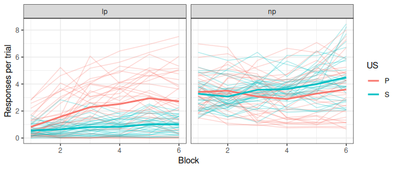

```r
pati |> ggplot(aes(x = block, y = rpert, colour = us)) +
  geom_line(aes(group = interaction(us, subject)), alpha = .3) +
  stat_summary(geom = "line", fun = "mean", linewidth = 1) +
  labs(x = "Block", y = "Responses per trial", colour = "US") +
  facet_grid(~response)
```

The thicker lines are group averages; the rest are individual subjects. We ignore the specific mapping between levers and USs here because that was counterbalanced across subjects. However, we will not ignore the counterbalancing when writing the model function (see ahead).

## Writing the model function

The biggest hurdle in fitting the model to empirical data is to write a function that, **given a vector of parameters and an experiment, generates responses that are organized as the empirical data**. Let’s begin by summarizing the data first, so we know what to aim for.

```r
pati_summ <- setDT(pati)[,
  list("rpert" = mean(rpert)),
  by = c("block", "us", "response")
]
# set order (relevant for the future)
setorder(pati_summ, block, response, us)
head(pati_summ)
```

```
#>    block     us response     rpert
#>    <num> <char>   <fctr>     <num>
#> 1:     1      P       lp 0.8195313
#> 2:     1      S       lp 0.5609375
#> 3:     1      P       np 3.4109375
#> 4:     1      S       np 3.2796875
#> 5:     2      P       lp 1.5738281
#> 6:     2      S       lp 0.6406250
```

So what do we have to design? The experiment presented by Patitucci et al. (2016) was fairly simple, and it can be reduced to the presentations of two levers, each followed by a different appetitive outcome. Here, we will assume that the two outcomes are independent from each other. We will also take some liberties with the number of trials we specify to reduce computing time.

But beware: HeiDI, like many learning models, is sensitive to order effects. We do not want the model to misfit the data because we happened to run our simulations with an unlucky run of trials. The arguments we prepare must reflect the behavior of the model after a “general” experimental procedure, and so, we address that issue by running several iterations of the experiment (each with random order of trials) and averaging all experiments before evaluating the likelihood of the parameters.

With that in mind, we now will prepare the experiment as you would pass to `run_experiment()`.

```r
# The design data.frame
des_df <- data.frame(
  group = c("CB1", "CB2"),
  training = c(
    "12L>(Pellet)/12R>(Sucrose)/12#L/12#R",
    "12L>(Sucrose)/12R>(Pellet)/12#L/12#R"
  )
)
# The parameters
# the actual parameter values don't matter,
# as our function will re-write them inside the optimizer call
parameters <- get_parameters(des_df,
  model = "HD2022"
)
# The arguments
experiment <- make_experiment(des_df,
  parameters = parameters, model = "HD2022",
  iterations = 4
)
experiment
```

[output not shown]

Note we specified two counterbalancings as groups.

We must reproduce the counterbalancings in the data we are trying to fit as close as possible. Otherwise, the optimization process might latch onto experimentally-irrelevant variables. For example, it can be seen in `pati` that there was more lever pressing whenever a lever was paired with pellets. If we didn’t counterbalance the identities of the levers and food rewards, the optimization might result in one of the levers being less salient than the other!

We can now begin to write the model function. First, it would be a good to see what results `run_experiment()` returns.

```r
exp_res <- run_experiment(experiment)
results(exp_res)
```

```
#> $activations
#>       group    phase  trial_type trial block_size      s1     value  model
#>      <char>   <char>      <char> <int>      <num>  <fctr>     <num> <char>
#>   1:    CB1 training  L>(Pellet)     1          4       L 0.4000000 HD2022
#>   2:    CB1 training R>(Sucrose)     2          4       L 0.0000000 HD2022
#>   3:    CB1 training          #L     3          4       L 0.4000000 HD2022
#>   4:    CB1 training          #R     4          4       L 0.0000000 HD2022
#>   5:    CB1 training  L>(Pellet)     5          4       L 0.4000000 HD2022
#>  ---
#> 380:    CB2 training          #R    44          4 Sucrose 0.0000000 HD2022
#> 381:    CB2 training L>(Sucrose)    45          4 Sucrose 0.4000000 HD2022
#> 382:    CB2 training  R>(Pellet)    46          4 Sucrose 0.0000000 HD2022
#> 383:    CB2 training          #L    47          4 Sucrose 0.3991293 HD2022
#> 384:    CB2 training          #R    48          4 Sucrose 0.0000000 HD2022
#>
```

[output cut: 70 more lines]

Although `results()` returns many model outputs, as I said earlier, we only care about one of them: `responses` (the model responses). With them, we can write our model function.

```r
my_model_function <- function(pars, exper, full = FALSE) {
  # extract the parameters from the model
  new_parameters <- parameters(exper)[[1]]
  # assign alphas
  new_parameters$alphas[] <- pars
  # reassign parameters to the experiment
  parameters(exper) <- new_parameters # note parameters method
  # running the model and selecting responses
  exp_res <- run_experiment(exper)
  # summarizing the model
  responses <- results(exp_res)$responses
  # calculate extra variables
  responses$response <- ifelse(responses$s1 %in% c("Pellet", "Sucrose"),
    "np", "lp"
  )
  responses$block <- ceiling(responses$trial / 8)
  # filtering
  # only probe trials
  responses <- responses[grepl("#", trial_type)]
  # only available responses
  responses <- responses[s2 %in% c("Pellet", "Sucrose") &
    (response == "np" | (response == "lp" &
      mapply(grepl, s1, trial_type)))]
  # aggregate
  responses <- responses[, list(value = mean(value)), by = c("block", "s2", "response")]
  if (full) {
    return(responses)
  }
  responses$value
}
```

That’s a lot to digest, so let’s see the function in action.

```r
my_model_function(c(.1, .2, .4, .3), experiment)
```

```
#>  [1] 0.028557609 0.040188221 0.004008696 0.008429327 0.045573899 0.061933782
#>  [7] 0.010480790 0.021230102 0.053426837 0.070862133 0.015100913 0.029677071
#> [13] 0.057584182 0.074995358 0.018328387 0.035165746 0.059994400 0.077081202
#> [19] 0.020711121 0.039013071 0.061492438 0.078227391 0.022547790 0.041891069
```

Just numbers!

The order of the empirical data and model responses must match. I cannot emphasize this point enough: there is nothing within the fit function that checks or reorders the data for you.

You are the sole responsible for making sure both of these pieces of data are in the same order. A simple way would be to print the model results before the return and compare them against the data. That’s the reason for the `full` parameter in the function definition.

```r
head(my_model_function(c(.1, .2, .4, .3), experiment, full = TRUE))
```

```
#>    block      s2 response       value
#>    <num>  <char>   <char>       <num>
#> 1:     1  Pellet       lp 0.028557609
#> 2:     1 Sucrose       lp 0.040188221
#> 3:     1  Pellet       np 0.004008696
#> 4:     1 Sucrose       np 0.008429327
#> 5:     2  Pellet       lp 0.045573899
#> 6:     2 Sucrose       lp 0.061933782
```

```r
head(pati_summ)
```

```
#>    block     us response     rpert
#>    <num> <char>   <fctr>     <num>
#> 1:     1      P       lp 0.8195313
#> 2:     1      S       lp 0.5609375
#> 3:     1      P       np 3.4109375
#> 4:     1      S       np 3.2796875
#> 5:     2      P       lp 1.5738281
#> 6:     2      S       lp 0.6406250
```

Once we have made sure everything is looking good, we can fit the model.

## Fitting the model

We fit models using the `fit_model()` function. This function requires 4 arguments:

1. The (empirical) data.
2. A model function.
3. The arguments with which to run the model function.
4. The optimizer options.

We have done a great job taking care of the first three, so let’s tackle the last.

```r
my_optimizer_opts <- get_optimizer_opts(
  model_pars = names(parameters$alphas),
  optimizer = "ga",
  ll = c(0, 0, 0, 0),
  ul = c(1, 1, 1, 1),
  family = "normal"
)
my_optimizer_opts
```

```
#> $model_pars
#> [1] "L"       "Pellet"  "R"       "Sucrose"
#>
#> $optimizer
#> [1] "ga"
#>
#> $family
#> [1] "normal"
#>
#> $family_pars
#> [1] "normal_scale"
#>
#> $all_pars
#> [1] "L"            "Pellet"       "R"            "Sucrose"      "normal_scale"
#>
#> $initial_pars
#> [1] NA NA NA NA  1
#>
#> $ll
#>            L       Pellet            R      Sucrose normal_scale
#>            0            0            0            0            0
#>
#> $ul
#>            L       Pellet            R      Sucrose normal_scale
#>            1            1            1            1          100
#>
#> $verbose
#> [1] FALSE
```

The `get_optimizer_opts()` function returns many things:

1. model_pars: The name of the model parameters (name of the alpha for each stimulus).
2. ll and ul: The lower and upper limits for the parameter search.
3. optimizer: The numerical optimization technique we wish to use during MLE estimation.
4. family: The family distribution we assume for our model. In practice, what you request here will be used to determine the link function to transform model responses, and the likelihood function used in the objective function. The normal family here does nothing fancy to the model responses but will estimate an extra parameter, scale, which scales the model responses into the scale of the empirical data. When it comes to likelihood functions, this family will use the normal density of the data and model differences.
5. family_pars: The family-specific parameter being estimated alongside salience parameters.
6. verbose: Whether to print parameters and objective function values as we optimize.

You are free to modify these; just make sure the structure of the list returned by `get_optimizer_opts()` remains the same.

We can also pass extra parameters to the optimizer call we are using (e.g., the `par` argument for `optim`, or `parallel` for `ga`). Here, we fit the model in parallel with `ga`, and for only 10 iterations.

And with that, we can fit the model! (be patient if you are following along)

```r
the_fit <- fit_model(pati_summ$rpert,
  model_function = my_model_function,
  exper = experiment,
  optimizer_options = my_optimizer_opts,
  maxiter = 10,
  parallel = TRUE
)
```

The `fit_model` function returns a lot of information to track what we put in and what we got out. However, typing the model in the console will show the MLE parameters we obtained this time and their negative log-likelihood, given the data:

```r
the_fit
# the BIC and AIC
BIC(the_fit)
```

[output not shown]

```
#> [1] 102.484
```

```r
AIC(the_fit)
```

```
#> [1] 96.5937
```

That’s good and all, but how well does a model run with those parameters “visually” fit the data? We can obtain the predictions from the model via the `predict` function.

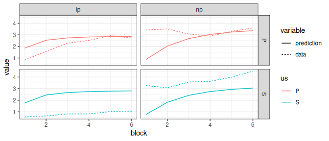

```r
pati_summ$prediction <- predict(the_fit, exper = experiment)
pati_summ[, data := rpert][, rpert := NULL]
pati_summ <- melt(pati_summ, measure.vars = c("prediction", "data"))
pati_summ |>
  ggplot(ggplot2::aes(
    x = block, y = value,
    colour = us,
    linetype = variable
  )) +
  geom_line() +
  theme_bw() +
  facet_grid(us ~ response)
```

This looks pretty good! Save from some blatant misfits, of course.

Now you know everything you need to fit `calmr` to your empirical data. Go forth!

### A final note

This vignette was pre-generated, as I don’t want the user to fit the model at the time of installation. I will try to keep up with it as the package develops, but if you spot any inconsistencies, please drop me a line.

[^1]: Note the `[[1]]` to get the first parameter lists; by default, `parameters` returns a named list after each group
[^2]: Within this step, we also filter all output nodes that are not related to expecting one of the USs, we classify responses as being nosepokes (produced by the food reward) or lever presses (produced by the levers), and calculate the mean across blocks of trials. Fitting a model is no trivial task!